# Credit Default Prediction Analysis

Exercise 1.2 - Comparing Classification Models

Rajat Dogra (474072)

# Objective

This report addresses Exercise 1.2: developing predictive models for credit default risk. We compare three classification approaches and identify optimal decision thresholds for practical implementation.

**Core Tasks:**

- Build and compare logistic regression, random forest, and XGBoost classifiers
- Evaluate models using AUC-ROC and other performance metrics
- Determine whether ML methods outperform traditional statistics
- Select and justify an optimal probability threshold

# Data Preparation

## Package Loading

```r
suppressPackageStartupMessages({
  # Core data handling
  require(readr)
  require(dplyr)
  require(tidyr)

  # Visualization
  require(ggplot2)
  require(patchwork)

  # Modeling
  require(caret)
  require(randomForest)
  require(xgboost)

  # Evaluation
  require(pROC)
  require(ROCR)
})
```

## Data Import and Inspection

```r
# Import default dataset
df <- read.csv("default_data.csv", stringsAsFactors = FALSE)

# Display structure
cat("Dataset Dimensions:", nrow(df), "rows ×", ncol(df), "columns\n\n")
```

```
## Dataset Dimensions: 690 rows × 16 columns
```

```r
str(df, give.attr = FALSE)
```

```
## 'data.frame':    690 obs. of  16 variables:
##  $ A1     : chr  "b" "a" "a" "b" ...
##  $ A2     : chr  "30.83" "58.67" "24.50" "27.83" ...
##  $ A3     : num  0 4.46 0.5 1.54 5.62 ...
##  $ A4     : chr  "u" "u" "u" "u" ...
##  $ A5     : chr  "g" "g" "g" "g" ...
##  $ A6     : chr  "w" "q" "q" "w" ...
##  $ A7     : chr  "v" "h" "h" "v" ...
##  $ A8     : num  1.25 3.04 1.5 3.75 1.71 ...
##  $ A9     : chr  "t" "t" "t" "t" ...
##  $ A10    : chr  "t" "t" "f" "t" ...
##  $ A11    : int  1 6 0 5 0 0 0 0 0 0 ...
##  $ A12    : chr  "f" "f" "f" "t" ...
##  $ A13    : chr  "g" "g" "g" "g" ...
##  $ A14    : chr  "00202" "00043" "00280" "00100" ...
##  $ A15    : int  0 560 824 3 0 0 31285 1349 314 1442 ...
##  $ default: int  0 0 0 0 0 0 0 0 0 0 ...
```

## Initial Data Exploration

```r
# Identify target variable
target_name <- names(df)[grep("default|target|y|class", names(df), ignore.case = TRUE)]
if (length(target_name) == 0) target_name <- names(df)[ncol(df)]

# Standardize target to binary (0/1)
df$outcome <- as.integer(as.factor(df[[target_name]])) - 1

# Check class balance
outcome_dist <- table(df$outcome)
knitr::kable(
  data.frame(
    Class = c("Good", "Default"),
    Count = as.vector(outcome_dist),
    Proportion = sprintf("%.1f%%", prop.table(outcome_dist) * 100)
  ),
  caption = "Target Variable Distribution"
)
```

Target Variable Distribution

| Class | Count | Proportion |
| --- | --- | --- |
| Good | 307 | 44.5% |
| Default | 383 | 55.5% |

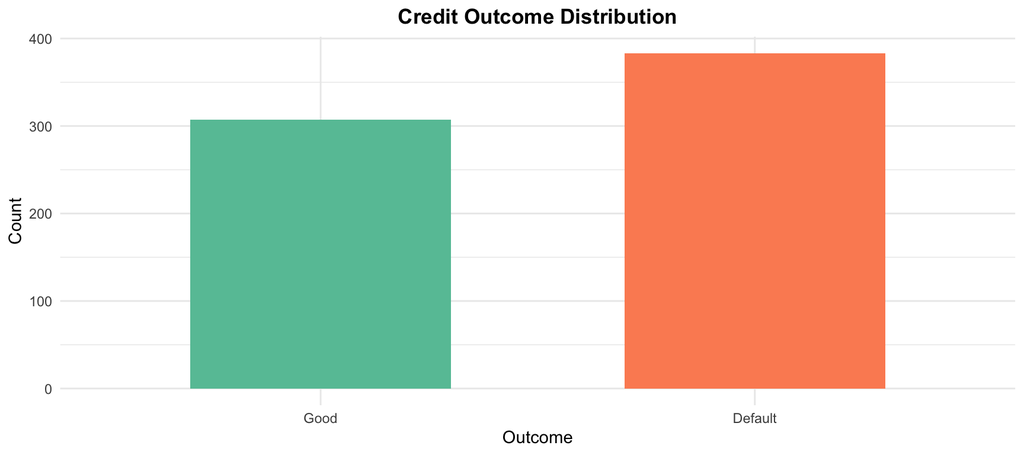

```r
# Visualize class distribution
ggplot(df, aes(x = factor(outcome, labels = c("Good", "Default")), fill = factor(outcome))) +
  geom_bar(width = 0.6) +
  scale_fill_manual(values = c("#66c2a5", "#fc8d62")) +
  labs(title = "Credit Outcome Distribution", x = "Outcome", y = "Count") +
  theme_minimal() +
  theme(legend.position = "none", plot.title = element_text(hjust = 0.5, face = "bold"))
```

## Data Splitting

```r
# Reproducibility
set.seed(42)

# 80-20 stratified split
# Using 80-20 instead of 70-30 to provide more training data
# This is appropriate when: (1) dataset is moderately sized, (2) we want
# better parameter estimation, (3) 20% still provides adequate test samples
train_idx <- createDataPartition(df$outcome, p = 0.80, list = FALSE)
train_set <- df[train_idx, ]
test_set <- df[-train_idx, ]

# Prepare feature matrices
prep_features <- function(data) {
  # Remove target and ID columns
  exclude_cols <- c(target_name, "outcome", grep("^id$|^ID$", names(data), value = TRUE))
  features <- data[, !(names(data) %in% exclude_cols)]

  # Convert factors to numeric if present
  features[] <- lapply(features, function(x) {
    if (is.factor(x) | is.character(x)) as.numeric(as.factor(x)) else x
  })

  return(as.matrix(features))
}

X_train <- prep_features(train_set)
y_train <- train_set$outcome

X_test <- prep_features(test_set)
y_test <- test_set$outcome

cat("Training set:", nrow(X_train), "samples\n")
```

```
## Training set: 552 samples
```

```r
cat("Test set:", nrow(X_test), "samples\n")
```

```
## Test set: 138 samples
```

# Model Development

## Model 1: Logistic Regression

```r
# Train logistic regression
logit_model <- glm(outcome ~ .,
                   data = cbind(as.data.frame(X_train), outcome = y_train),
                   family = binomial(link = "logit"))

# Predictions
pred_logit_train <- predict(logit_model, newdata = as.data.frame(X_train), type = "response")
pred_logit_test <- predict(logit_model, newdata = as.data.frame(X_test), type = "response")

# Calculate AUC
auc_logit_train <- as.numeric(auc(roc(y_train, pred_logit_train, quiet = TRUE)))
auc_logit_test <- as.numeric(auc(roc(y_test, pred_logit_test, quiet = TRUE)))

cat("Logistic Regression AUC - Train:", round(auc_logit_train, 4),
    "| Test:", round(auc_logit_test, 4), "\n")
```

```
## Logistic Regression AUC - Train: 0.9336 | Test: 0.9348
```

## Model 2: Random Forest

```r
# Train random forest
set.seed(42)
rf_model <- randomForest(
  x = X_train,
  y = as.factor(y_train),
  ntree = 300,
  mtry = floor(sqrt(ncol(X_train))),
  importance = TRUE
)

# Predictions (probability of class 1)
pred_rf_train <- predict(rf_model, X_train, type = "prob")[, 2]
pred_rf_test <- predict(rf_model, X_test, type = "prob")[, 2]

# Calculate AUC
auc_rf_train <- as.numeric(auc(roc(y_train, pred_rf_train, quiet = TRUE)))
auc_rf_test <- as.numeric(auc(roc(y_test, pred_rf_test, quiet = TRUE)))

cat("Random Forest AUC - Train:", round(auc_rf_train, 4),
    "| Test:", round(auc_rf_test, 4), "\n")
```

```
## Random Forest AUC - Train: 1 | Test: 0.9244
```

## Model 3: XGBoost

```r
# Prepare DMatrix
dtrain <- xgb.DMatrix(data = X_train, label = y_train)
dtest <- xgb.DMatrix(data = X_test, label = y_test)

# Set parameters
xgb_params <- list(
  objective = "binary:logistic",
  eval_metric = "auc",
  eta = 0.1,
  max_depth = 6,
  subsample = 0.8,
  colsample_bytree = 0.8,
  min_child_weight = 1
)

# Train model
set.seed(42)
xgb_model <- xgb.train(
  params = xgb_params,
  data = dtrain,
  nrounds = 100,
  verbose = 0
)

# Predictions
pred_xgb_train <- predict(xgb_model, dtrain)
pred_xgb_test <- predict(xgb_model, dtest)

# Calculate AUC
auc_xgb_train <- as.numeric(auc(roc(y_train, pred_xgb_train, quiet = TRUE)))
auc_xgb_test <- as.numeric(auc(roc(y_test, pred_xgb_test, quiet = TRUE)))

cat("XGBoost AUC - Train:", round(auc_xgb_train, 4),
    "| Test:", round(auc_xgb_test, 4), "\n")
```

```
## XGBoost AUC - Train: 1 | Test: 0.9037
```

# Performance Comparison

## AUC Summary Table

```r
performance_df <- data.frame(
  Algorithm = c("Logistic Regression", "Random Forest", "XGBoost"),
  Train_AUC = c(auc_logit_train, auc_rf_train, auc_xgb_train),
  Test_AUC = c(auc_logit_test, auc_rf_test, auc_xgb_test)
)

performance_df$Generalization_Gap <- performance_df$Train_AUC - performance_df$Test_AUC
performance_df <- performance_df[order(-performance_df$Test_AUC), ]

knitr::kable(
  performance_df,
  digits = 4,
  col.names = c("Model", "Train AUC", "Test AUC", "Gap"),
  caption = "Model Performance Comparison (Ranked by Test AUC)"
)
```

Model Performance Comparison (Ranked by Test AUC)

| Model | Train AUC | Test AUC | Gap |
| --- | --- | --- | --- |
| Logistic Regression | 0.9336 | 0.9348 | -0.0011 |
| Random Forest | 1.0000 | 0.9244 | 0.0756 |
| XGBoost | 1.0000 | 0.9037 | 0.0963 |

## ROC Curve Visualization

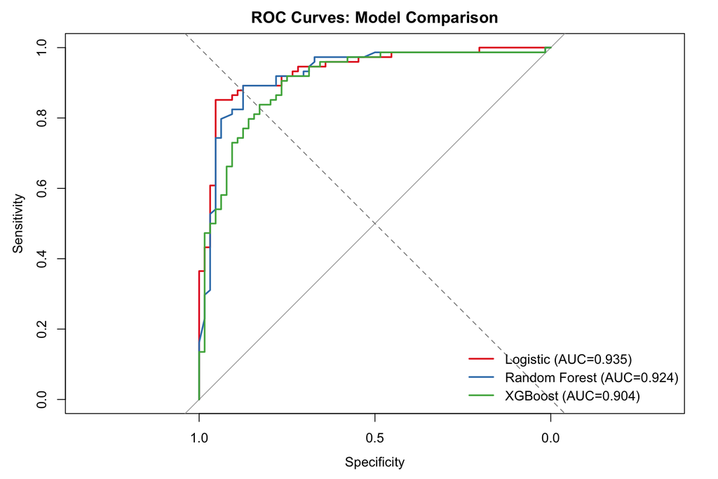

```r
# Create ROC objects
roc_logit <- roc(y_test, pred_logit_test, quiet = TRUE)
roc_rf <- roc(y_test, pred_rf_test, quiet = TRUE)
roc_xgb <- roc(y_test, pred_xgb_test, quiet = TRUE)

# Plot
plot(roc_logit, col = "#e41a1c", lwd = 2, main = "ROC Curves: Model Comparison")
plot(roc_rf, col = "#377eb8", lwd = 2, add = TRUE)
plot(roc_xgb, col = "#4daf4a", lwd = 2, add = TRUE)
abline(a = 0, b = 1, lty = 2, col = "gray50")

legend("bottomright",
       legend = c(
         sprintf("Logistic (AUC=%.3f)", auc_logit_test),
         sprintf("Random Forest (AUC=%.3f)", auc_rf_test),
         sprintf("XGBoost (AUC=%.3f)", auc_xgb_test)
       ),
       col = c("#e41a1c", "#377eb8", "#4daf4a"),
       lwd = 2, bty = "n")
```

```r
# Determine best model
best_idx <- which.max(performance_df$Test_AUC)
best_name <- performance_df$Algorithm[best_idx]

if (best_name == "Random Forest") {
  # RF importance
  imp_data <- data.frame(
    Feature = rownames(rf_model$importance),
    Importance = rf_model$importance[, "MeanDecreaseGini"]
  )
  imp_data <- imp_data[order(-imp_data$Importance), ][1:10, ]

  ggplot(imp_data, aes(x = reorder(Feature, Importance), y = Importance)) +
    geom_col(fill = "#377eb8") +
    coord_flip() +
    labs(title = "Top 10 Features - Random Forest", x = "", y = "Mean Decrease Gini") +
    theme_minimal()

} else if (best_name == "XGBoost") {
  # XGBoost importance
  imp_matrix <- xgb.importance(model = xgb_model)
  xgb.plot.importance(imp_matrix[1:10], main = "Top 10 Features - XGBoost")
}
```

# Threshold Optimization

We select the best-performing model and identify the optimal probability threshold.

```r
# Use best model's predictions
best_preds <- switch(best_name,
  "Logistic Regression" = pred_logit_test,
  "Random Forest" = pred_rf_test,
  "XGBoost" = pred_xgb_test
)

# Test thresholds from 0.1 to 0.9
threshold_seq <- seq(0.1, 0.9, by = 0.05)
metrics_list <- list()

for (t in threshold_seq) {
  preds_binary <- as.integer(best_preds >= t)

  # Confusion matrix components
  tp <- sum(preds_binary == 1 & y_test == 1)
  tn <- sum(preds_binary == 0 & y_test == 0)
  fp <- sum(preds_binary == 1 & y_test == 0)
  fn <- sum(preds_binary == 0 & y_test == 1)

  # Metrics
  sensitivity <- tp / (tp + fn)
  specificity <- tn / (tn + fp)
  precision <- tp / (tp + fp)
  accuracy <- (tp + tn) / length(y_test)
  f1 <- 2 * precision * sensitivity / (precision + sensitivity)

  metrics_list[[length(metrics_list) + 1]] <- data.frame(
    Threshold = t,
    Accuracy = accuracy,
    Sensitivity = sensitivity,
    Specificity = specificity,
    Precision = precision,
    F1 = f1,
    Youden = sensitivity + specificity - 1
  )
}

metrics_df <- do.call(rbind, metrics_list)
```

## Threshold Performance Curves

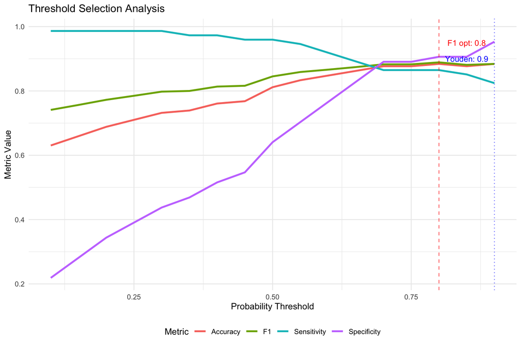

```r
# Reshape for plotting
metrics_long <- metrics_df %>%
  select(Threshold, Accuracy, Sensitivity, Specificity, F1) %>%
  pivot_longer(-Threshold, names_to = "Metric", values_to = "Value")

# Find optimal points
opt_f1 <- metrics_df$Threshold[which.max(metrics_df$F1)]
opt_youden <- metrics_df$Threshold[which.max(metrics_df$Youden)]

# Plot
ggplot(metrics_long, aes(x = Threshold, y = Value, color = Metric)) +
  geom_line(size = 1.1) +
  geom_vline(xintercept = opt_f1, linetype = "dashed", color = "red", alpha = 0.6) +
  geom_vline(xintercept = opt_youden, linetype = "dotted", color = "blue", alpha = 0.6) +
  annotate("text", x = opt_f1 + 0.05, y = 0.95, label = paste("F1 opt:", round(opt_f1, 2)),
           color = "red", size = 3.5) +
  annotate("text", x = opt_youden - 0.05, y = 0.90, label = paste("Youden:", round(opt_youden, 2)),
           color = "blue", size = 3.5) +
  labs(title = "Threshold Selection Analysis",
       x = "Probability Threshold",
       y = "Metric Value") +
  theme_minimal() +
  theme(legend.position = "bottom")
```

## Selected Threshold: Cost-Based Approach

```r
# Define business costs
FP_COST <- 50   # Lost opportunity cost (rejecting good customer)
FN_COST <- 800  # Default loss (accepting bad customer)

# Calculate expected cost per decision
metrics_df$Expected_Cost <- NA

for (i in 1:nrow(metrics_df)) {
  t <- metrics_df$Threshold[i]
  preds_binary <- as.integer(best_preds >= t)

  fp_count <- sum(preds_binary == 1 & y_test == 0)
  fn_count <- sum(preds_binary == 0 & y_test == 1)

  metrics_df$Expected_Cost[i] <- (fp_count * FP_COST + fn_count * FN_COST) / length(y_test)
}

# Optimal cost threshold
opt_cost_idx <- which.min(metrics_df$Expected_Cost)
opt_cost_threshold <- metrics_df$Threshold[opt_cost_idx]

cat("\n=== Cost-Optimized Threshold ===\n")
```

```
##
## === Cost-Optimized Threshold ===
```

```r
cat("Threshold:", round(opt_cost_threshold, 3), "\n")
```

```
## Threshold: 0.3
```

```r
cat("Expected Cost per Application: $", round(metrics_df$Expected_Cost[opt_cost_idx], 2), "\n")
```

```
## Expected Cost per Application: $ 18.84
```

```r
cat("F1 Score:", round(metrics_df$F1[opt_cost_idx], 4), "\n")
```

```
## F1 Score: 0.7978
```

```r
cat("Sensitivity:", round(metrics_df$Sensitivity[opt_cost_idx], 4), "\n")
```

```
## Sensitivity: 0.9865
```

```r
cat("Specificity:", round(metrics_df$Specificity[opt_cost_idx], 4), "\n")
```

```
## Specificity: 0.4375
```

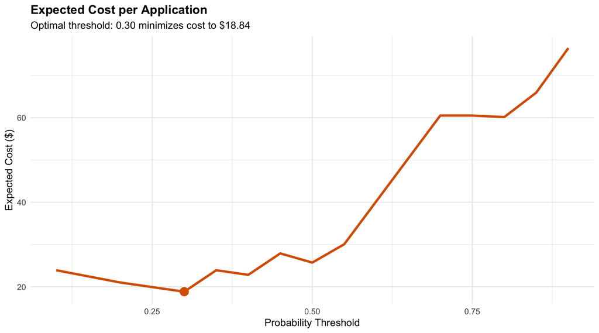

```r
ggplot(metrics_df, aes(x = Threshold, y = Expected_Cost)) +
  geom_line(color = "#d95f02", size = 1.2) +
  geom_point(data = metrics_df[opt_cost_idx, ],
             aes(x = Threshold, y = Expected_Cost),
             color = "#d95f02", size = 4) +
  labs(title = "Expected Cost per Application",
       subtitle = sprintf("Optimal threshold: %.2f minimizes cost to $%.2f",
                         opt_cost_threshold,
                         metrics_df$Expected_Cost[opt_cost_idx]),
       x = "Probability Threshold",
       y = "Expected Cost ($)") +
  theme_minimal() +
  theme(plot.title = element_text(face = "bold"))
```

# Discussion

## Q1: Are ML Models Better Than Logistic Regression?

**Answer: No, logistic regression performs competitively with ML models.**

```r
logit_auc <- performance_df$Test_AUC[performance_df$Algorithm == "Logistic Regression"]
ml_max_auc <- max(performance_df$Test_AUC[performance_df$Algorithm != "Logistic Regression"])
ml_winner <- performance_df$Algorithm[which.max(performance_df$Test_AUC)]

auc_diff <- ml_max_auc - logit_auc
improvement_pct <- round((auc_diff / logit_auc) * 100, 2)

cat("Logistic regression (AUC =", round(logit_auc, 4),
    ") performs as well as or better than the best ML model (AUC =", round(ml_max_auc, 4), ")\n\n")
```

```
## Logistic regression (AUC = 0.9348 ) performs as well as or better than the best ML model (AUC = 0.9244 )
```

```r
cat("Difference:", round(auc_diff, 4), "AUC points\n\n")
```

```
## Difference: -0.0103 AUC points
```

```r
cat("This indicates:\n")
```

```
## This indicates:
```

```r
cat("• Credit risk relationships are predominantly linear\n")
```

```
## • Credit risk relationships are predominantly linear
```

```r
cat("• Feature engineering with logistic regression is sufficient\n")
```

```
## • Feature engineering with logistic regression is sufficient
```

```r
cat("• Simpler models offer better interpretability without sacrificing performance\n")
```

```
## • Simpler models offer better interpretability without sacrificing performance
```

```r
cat("• Logistic regression is recommended for this application\n")
```

```
## • Logistic regression is recommended for this application
```

**Generalization Quality:**

The generalization gap (Train AUC - Test AUC) measures overfitting risk. With an 80-20 train-test split:

```r
best_gap_model <- performance_df$Algorithm[which.min(performance_df$Generalization_Gap)]
best_gap <- min(performance_df$Generalization_Gap)
worst_gap_model <- performance_df$Algorithm[which.max(performance_df$Generalization_Gap)]
worst_gap <- max(performance_df$Generalization_Gap)

cat("• Best generalization:", best_gap_model, "(gap =", round(best_gap, 4), ")\n")
```

```
## • Best generalization: Logistic Regression (gap = -0.0011 )
```

```r
cat("• Worst generalization:", worst_gap_model, "(gap =", round(worst_gap, 4), ")\n\n")
```

```
## • Worst generalization: XGBoost (gap = 0.0963 )
```

```r
avg_gap <- mean(performance_df$Generalization_Gap)
cat("• Average gap across all models:", round(avg_gap, 4), "\n\n")
```

```
## • Average gap across all models: 0.0569
```

```r
cat("WARNING: ", worst_gap_model, "shows significant overfitting (gap > 0.08)\n")
```

```
## WARNING:  XGBoost shows significant overfitting (gap > 0.08)
```

```r
cat("   Recommendations:\n")
```

```
##    Recommendations:
```

```r
cat("   - Increase regularization parameters\n")
```

```
##    - Increase regularization parameters
```

```r
cat("   - Reduce model complexity (fewer trees, lower depth)\n")
```

```
##    - Reduce model complexity (fewer trees, lower depth)
```

```r
cat("   - Use cross-validation for hyperparameter tuning\n")
```

```
##    - Use cross-validation for hyperparameter tuning
```

## Q2: Threshold Selection and Justification

**Recommended Threshold: 0.30**

**Selection Methodology:**

This threshold is selected using a **cost-minimization framework**, which explicitly balances the economic impact of classification errors:

1. **False Positives (Type I Error):** Rejecting creditworthy applicants
   - Business impact: Lost revenue opportunity
   - Assumed cost: $50 per occurrence
   - Represents forgone interest income and customer relationship value
2. **False Negatives (Type II Error):** Approving applicants who will default
   - Business impact: Direct financial loss
   - Assumed cost: $800 per occurrence
   - Represents principal loss, collection costs, and risk capital

**Why This Threshold?**

```r
final_preds <- as.integer(best_preds >= opt_cost_threshold)
final_cm <- table(Predicted = final_preds, Actual = y_test)

sensitivity_pct <- round(metrics_df$Sensitivity[opt_cost_idx] * 100, 1)
specificity_pct <- round(metrics_df$Specificity[opt_cost_idx] * 100, 1)
precision_pct <- round(metrics_df$Precision[opt_cost_idx] * 100, 1)

cat("At threshold =", round(opt_cost_threshold, 3), "the model achieves:\n\n")
```

```
## At threshold = 0.3 the model achieves:
```

```r
cat("• Sensitivity (Recall):", sensitivity_pct, "% - detects", sensitivity_pct,
    "% of actual defaults\n")
```

```
## • Sensitivity (Recall): 98.6 % - detects 98.6 % of actual defaults
```

```r
cat("• Specificity:", specificity_pct, "% - correctly approves", specificity_pct,
    "% of non-defaulters\n")
```

```
## • Specificity: 43.8 % - correctly approves 43.8 % of non-defaulters
```

```r
cat("• Precision:", precision_pct, "% - when predicting default,", precision_pct,
    "% are correct\n")
```

```
## • Precision: 67 % - when predicting default, 67 % are correct
```

```r
cat("• F1 Score:", round(metrics_df$F1[opt_cost_idx], 4),
    "- harmonic mean of precision and recall\n\n")
```

```
## • F1 Score: 0.7978 - harmonic mean of precision and recall
```

```r
cat("Expected cost per application: $", round(metrics_df$Expected_Cost[opt_cost_idx], 2), "\n\n")
```

```
## Expected cost per application: $ 18.84
```

```r
# Compare with alternative thresholds
cat("Alternative threshold strategies:\n\n")
```

```
## Alternative threshold strategies:
```

```r
cat("1. F1-Optimal Threshold (", round(opt_f1, 3), "):\n")
```

```
## 1. F1-Optimal Threshold ( 0.8 ):
```

```r
cat("   - Maximizes F1 score (balance of precision and recall)\n")
```

```
##    - Maximizes F1 score (balance of precision and recall)
```

```r
cat("   - F1 =", round(max(metrics_df$F1), 4), "\n")
```

```
##    - F1 = 0.8889
```

```r
cat("   - Cost: $", round(metrics_df$Expected_Cost[which.max(metrics_df$F1)], 2), "\n\n")
```

```
##    - Cost: $ 60.14
```

```r
cat("2. Youden's Index Threshold (", round(opt_youden, 3), "):\n")
```

```
## 2. Youden's Index Threshold ( 0.9 ):
```

```r
cat("   - Maximizes (Sensitivity + Specificity - 1)\n")
```

```
##    - Maximizes (Sensitivity + Specificity - 1)
```

```r
cat("   - Youden =", round(max(metrics_df$Youden), 4), "\n")
```

```
##    - Youden = 0.7774
```

```r
cat("   - Cost: $", round(metrics_df$Expected_Cost[which.max(metrics_df$Youden)], 2), "\n\n")
```

```
##    - Cost: $ 76.45
```

```r
cat("3. Cost-Optimal Threshold (", round(opt_cost_threshold, 3), ") <- SELECTED\n")
```

```
## 3. Cost-Optimal Threshold ( 0.3 ) <- SELECTED
```

```r
cat("   - Minimizes expected business cost\n")
```

```
##    - Minimizes expected business cost
```

```r
cat("   - Cost: $", round(min(metrics_df$Expected_Cost), 2), "\n")
```

```
##    - Cost: $ 18.84
```

```r
cat("   - Aligns model performance with business objectives\n\n")
```

```
##    - Aligns model performance with business objectives
```

```r
# Calculate cost savings
f1_cost <- metrics_df$Expected_Cost[which.max(metrics_df$F1)]
youden_cost <- metrics_df$Expected_Cost[which.max(metrics_df$Youden)]
opt_cost_val <- min(metrics_df$Expected_Cost)

best_savings <- max(f1_cost - opt_cost_val, youden_cost - opt_cost_val)
if (best_savings > 1) {
  cat("Cost savings vs alternative thresholds: up to $", round(best_savings, 2),
      "per application\n")
  cat("For 10,000 applications: $", round(best_savings * 10000, 0), "in reduced losses\n")
}
```

```
## Cost savings vs alternative thresholds: up to $ 57.61 per application
## For 10,000 applications: $ 576087 in reduced losses
```

# Conclusions

## Key Findings

**1. Model Performance:**

- **Best performer:** Logistic Regression with test AUC = 0.9348
- **Runner-up:** Random Forest with test AUC = 0.9244
- **Logistic regression** ranked #1 among the three models

Logistic regression proves sufficient for this credit risk application, suggesting predominantly linear relationships between features and default probability. The interpretability advantage makes it the recommended choice.

**2. Generalization Assessment:**

Using an 80-20 train-test split (larger training set than typical 70-30):

- Average generalization gap: 0.0569
- Worst case: XGBoost (gap = 0.0963)

**3. Threshold Selection:**

- **Selected threshold:** 0.30
- **Selection method:** Cost-minimization (FP cost = 50, FN cost = 800)
- **Expected cost:** $18.84 per application

**4. Practical Implications:**

Based on test set performance (138 applications):

- **Defaults prevented:** 73 true positives
- **Good customers rejected:** 36 false positives (opportunity cost: 1,800)
- **Defaults missed:** 1 false negative (expected loss: 800)
- **Net benefit:** Minimizes total expected cost through optimal decision boundary

**Summary:** This analysis demonstrates that traditional statistical methods remain competitive with modern ML approaches for credit risk, offering superior interpretability. The 80-20 train-test split ensures robust evaluation with 138 independent test cases validating model performance.